# Quantification of extremal responses in simulated dynamic structures

Lachlan Astfalck

January 07, 2019

This document demonstrates the research presented in Chapter 5. First, a synthetic dataset is generated, then methodology is demonstrated, and finally the diagnostics are presented.

# Generation of synthetic dataset

As the original dataset used within the research is confidential, the methodologies presented are demonstrated herein using a synthetic dataset. The dataset is generated so as to be similar to the original data.

First, we specify the number of training and validation points, and dimensions. As to align with the original research, this tutorial is presented for a single input dimension.

```r
N <- 80
N_predict <- 450
N_total <- N + N_predict
dim <- 1
```

Now, we generate a Latin hypercube spacing over the inputs, randomly sample the training points, and assign the remainder to act as validation points.

```r
x_lhs <- maximinLHS(N_total, dim)

sample_index <- sample(c(1:N_total), N, replace = FALSE)

x_train <- x_lhs[sample_index,]
x_pred <- x_lhs[-sample_index,]

x_all <- c(x_train, x_pred)
```

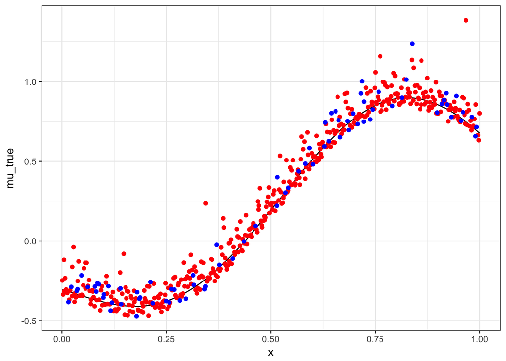

```r
xi <- 0.2
sigma <- 0.05
alpha <- 3
rho <- 0.2

SE <- function(d,alpha,rho) {
  alpha * exp(-d^2/(2*rho))
}

d <- as.matrix(dist(x_all))
K_mu <- SE(d, alpha, rho)

mu_true <- as.vector(rmvnorm(1,rep(0,N_total),K_mu))

y_true <- as.vector(rgev(N_total, mu_true, sigma, xi))

df_true <- data.frame(x = x_all,
                      mu_true = mu_true,
                      y_true = y_true)

ggplot() +
  geom_line(data = df_true, aes(x = x, y = mu_true)) +
  geom_point(data = df_true[(N+1):N_total, ],
             aes(x = x, y = y_true),
             colour = "red" ) +
  geom_point(data = df_true[1:N, ],
             aes(x = x, y = y_true),
             colour = "blue")
```

# Sampling the GEV model

The stan model to estimate the model from the “observed” data given below, and saved in the object `synth_gev`.

```stan
functions {
  vector gp_pred_rng(real[] x2,
                     vector z1, real[] x1,
                     real alpha, real rho, real delta) {
    int N1 = rows(z1);
    int N2 = size(x2);
    vector[N2] f2;
    {
      matrix[N1, N1] K =   cov_exp_quad(x1, alpha, rho) + diag_matrix(rep_vector(1e-06, N1));
      matrix[N1, N1] L_K = cholesky_decompose(K);

      vector[N1] L_K_div_z1 = mdivide_left_tri_low(L_K, z1);
      vector[N1] K_div_z1 = mdivide_right_tri_low(L_K_div_z1', L_K)';
      matrix[N1, N2] k_x1_x2 = cov_exp_quad(x1, x2, alpha, rho);
      vector[N2] f2_mu = (k_x1_x2' * K_div_z1);
      matrix[N1, N2] v_pred = mdivide_left_tri_low(L_K, k_x1_x2);
      matrix[N2, N2] cov_f2 =   cov_exp_quad(x2, alpha, rho) - v_pred' * v_pred
                              + diag_matrix(rep_vector(delta, N2));
      f2 = multi_normal_rng(f2_mu, cov_f2);
    }
    return f2;
  }
}

data {
  int<lower=1> N;

  real x[N];
  vector[N] y;

  int<lower=1> N_predict;
  real x_predict[N_predict];
}

parameters {
  real<lower=0> rho_mu;
  real<lower=0> alpha_mu;
  real<lower=-0.5,upper=0.5> xi;
  real<lower = 0> sigma;
  vector[N] mu_latent;
}

model {
  matrix[N, N] cov_mu =   cov_exp_quad(x, alpha_mu, rho_mu) + diag_matrix(rep_vector(1e-06, N));
  matrix[N, N] L_cov_mu = cholesky_decompose(cov_mu);

  real t_x[N];

  rho_mu ~ normal(0, 20.0 / 3);
  alpha_mu ~ normal(0, 2);

  xi ~ normal(0,1);

  mu_latent ~ multi_normal_cholesky(rep_vector(0, N), L_cov_mu);

  for (i in 1:N) {
    if (xi == 0 ) {
      t_x[i] = exp(-(y[i]-mu_latent[i])/sigma);
      } else {
      t_x[i] = (1 + xi * (y[i] - mu_latent[i]) / sigma)^(-1/xi);
    }
    target += - log(sigma) + (xi + 1) * log(t_x[i]) - (t_x[i]);
  }

}

generated quantities {
  vector[N_predict] mu_predict = gp_pred_rng(x_predict, mu_latent, x, alpha_mu, rho_mu, 1e-10);
}
```

To estimate the model parameters, we specify the training data in a list, along with the points that we wish to validate the model at. The specification of `N_predict` and `x_predict` are not necessary here, they simply allow for the efficient computation of the predictive quantities of $\boldsymbol{\mu}$ in the `generated_quantities` section of the stan model. We initialise the model at the true parameter values. In practice we do not know these quantities, however for the purposes of exposition we save ourselves much heartache and start in the sampler in the correct posterior location.

[output not shown]

[figure not shown]

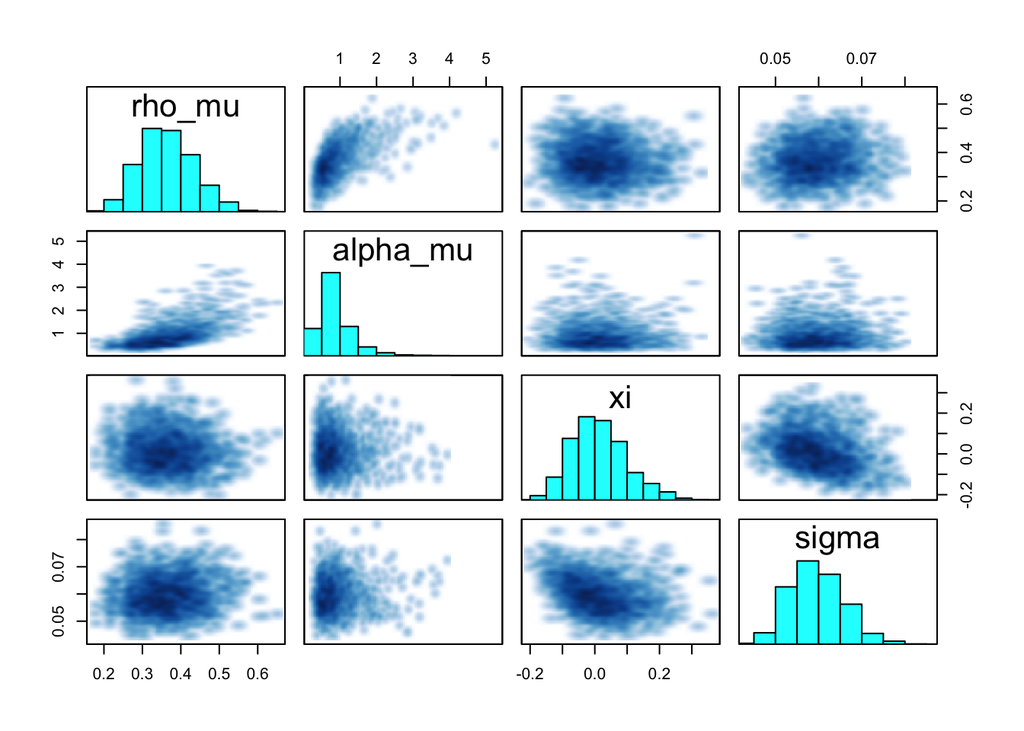

```r
rstan_options(auto_write = TRUE)
options(mc.cores = parallel::detectCores())

data <- list(N = N,
             x = x_train,
             y = df_true$y_true[1:N],
             N_predict = N_predict,
             x_predict = x_pred)

param_list <- list(rho_mu = rho,
                   alpha_mu = alpha,
                   xi = xi,
                   sigma = sigma,
                   mu_latent = df_true$mu_true[1:N])

gev_fit_synth <- stan(file=synth_gev,
                      data=data,
                      seed=5838298,
                      iter = 5000,
                      warmup = 1000,
                      init = list(param_list,
                                  param_list,
                                  param_list,
                                  param_list),
                      control = list(adapt_delta = 0.99, max_treedepth = 15))

pairs(gev_fit_synth, pars = c("rho_mu", "alpha_mu", "xi", "sigma"))
```

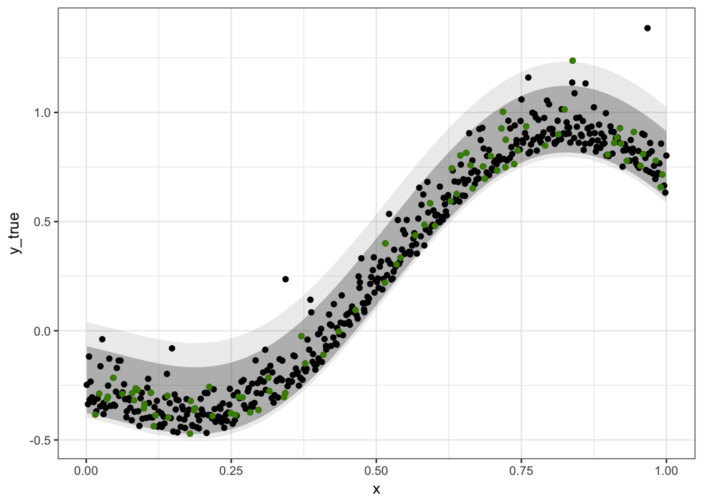

```r
gev_fit_extract <- extract(gev_fit_synth)

sample_length <- dim(gev_fit_extract$xi)

quant_gev_stan <- function (stan_list, sample_length, N_predict, q) {
  quant <- data.frame(matrix(NA, nrow = sample_length, ncol = N_predict))
  for (i in 1:sample_length) {
    quant[i, ] <- qgev(rep(q, N_predict), as.numeric(stan_list$mu_predict[i, ]),
                       stan_list$sigma[i], stan_list$xi[i])
  }
  return(quant)
}

qgev_list <- lapply(
  c(0.005,0.025,0.975,0.995),
  function(q) {
    apply(
      quant_gev_stan(gev_fit_extract, sample_length/4, N_predict, q),
      2,
      mean)
  }
)

qgev_pred_df <- data.frame(matrix(unlist(qgev_list), nrow = N_predict))
names(qgev_pred_df) <- c("q005","q025","q975","q995")
qgev_pred_df$x <- df_true$x[(N+1):N_total]

ggplot(data = qgev_pred_df, aes(x = x)) +
  geom_ribbon(aes(ymin = q025, ymax = q975), alpha = 0.3) +
  geom_ribbon(aes(ymin = q005, ymax = q995), alpha = 0.1) +
  geom_point(data = df_true, aes(y = y_true)) +
  geom_point(data = df_true[1:N, ], aes(y = y_true), color = "chartreuse4")
```